# 🏎️ Nina's F1 Predictions: 2026 Miami Grand Prix (Round 4)

## Miami International Autodrome — May 1-3, 2026

**Model version:** v1.0+Q (retrospective) **Confidence:** HIGH

### What This Is

A machine learning model that predicts Formula 1 race results from 24 features — the same kinds of data a race engineer considers when building race strategy. The model trains on every race through the round before this one (2026 weighted 10x over 2023-2025 history), takes the **actual qualifying grid** and **live qualifying sector times** for this weekend, then runs 10,000 simulated races to estimate podium probabilities.

> **This is a reconstructed prediction.** The model was rebuilt using only data available before the Miami GP — nothing from the race itself enters the model — so the accuracy check in the final section is a fair test. It backfills the season scoreboard for a race weekend that ran before the model was caught up.

```
============================================================
  🤖 XGBOOST v1.0 — 24 features, trained through Round 3
============================================================
  Training rows: 1,463
  Leave-one-out MAE: 2.37 positions (honest)
  Residual StdDev:   2.82

  Top features:
    grid_position             0.222
    car_speed                 0.109
    sector1_delta             0.098
    driver_avg_finish         0.067
    team_pit_strategy         0.057
    car_pace                  0.048
    sector3_delta             0.040
    team_changed              0.039
```

## 1. Qualifying & Blended Car Pace

Grid position is the model's single strongest predictor. This weekend's actual qualifying result sets the starting grid, and the team-level pace is a 30/70 blend of season-to-date form and qualifying performance. Live Miami sector deltas from qualifying replace the historical track profile.

```
======================================================================
  🏁 QUALIFYING GRID — 2026 Miami GP
======================================================================

  Pos  Driver                  Team                Blend Pace
  ------------------------------------------------------------
  P 1  Kimi Antonelli          Mercedes            P   2.6
  P 2  Max Verstappen          Red Bull Racing     P  11.9
  P 3  Charles Leclerc         Ferrari             P   4.3
  P 4  Lando Norris            McLaren             P   7.4
  P 5  George Russell          Mercedes            P   2.6
  P 6  Lewis Hamilton          Ferrari             P   4.3
  P 7  Oscar Piastri           McLaren             P   7.4
  P 8  Franco Colapinto        Alpine              P   9.1
  P 9  Pierre Gasly            Alpine              P   9.1
  P10  Nico Hulkenberg         Audi                P  15.2
  P11  Liam Lawson             Racing Bulls        P  12.6
  P12  Oliver Bearman          Haas F1 Team        P  12.5
  P13  Carlos Sainz            Williams            P  14.4
  P14  Esteban Ocon            Haas F1 Team        P  12.5
  P15  Alexander Albon         Williams            P  14.4
  P16  Arvid Lindblad          Racing Bulls        P  12.6
  P17  Fernando Alonso         Aston Martin        P  17.7
  P18  Lance Stroll            Aston Martin        P  17.7
  P19  Valtteri Bottas         Cadillac            P  18.6
  P20  Sergio Perez            Cadillac            P  18.6
  P21  Gabriel Bortoleto       Audi                P  15.2
  P22  Isack Hadjar            Red Bull Racing     P  11.9

  🌡️ Race conditions: 27.1°C, 70% humidity, WET
```

## 2. Predicted Finish

Each driver's predicted finishing position, with the inputs that drove it: grid (actual qualifying), car (blended team pace), and the position change the model expects relative to the grid.

```
================================================================================
  🏁 PREDICTED FINISH — 2026 Miami GP
================================================================================

  Pos  Driver                  Team                Grid   Pred  ΔGrid
  ----------------------------------------------------------------------
  P 1  Kimi Antonelli          Mercedes            P 1  P 1.3      =
  P 2  Charles Leclerc         Ferrari             P 3  P 3.0     +1
  P 3  Lando Norris            McLaren             P 4  P 3.3     +1
  P 4  Max Verstappen          Red Bull Racing     P 2  P 3.3     -2
  P 5  George Russell          Mercedes            P 5  P 3.9      =
  P 6  Lewis Hamilton          Ferrari             P 6  P 6.4      =
  P 7  Oscar Piastri           McLaren             P 7  P 7.0      =
  P 8  Oliver Bearman          Haas F1 Team        P12  P 8.3     +4
  P 9  Pierre Gasly            Alpine              P 9  P 9.1      =
  P10  Nico Hulkenberg         Audi                P10  P10.0      =
  P11  Franco Colapinto        Alpine              P 8  P11.1     -3
  P12  Carlos Sainz            Williams            P13  P11.6     +1
  P13  Esteban Ocon            Haas F1 Team        P14  P12.4     +1
  P14  Liam Lawson             Racing Bulls        P11  P12.8     -3
  P15  Isack Hadjar            Red Bull Racing     P22  P13.1     +7
  P16  Alexander Albon         Williams            P15  P13.2     -1
  P17  Arvid Lindblad          Racing Bulls        P16  P13.7     -1
  P18  Gabriel Bortoleto       Audi                P21  P14.1     +3
  P19  Lance Stroll            Aston Martin        P18  P16.0     -1
  P20  Fernando Alonso         Aston Martin        P17  P16.1     -3
  P21  Sergio Perez            Cadillac            P20  P16.9     -1
  P22  Valtteri Bottas         Cadillac            P19  P17.8     -3
```

## 3. Podium Probabilities (10,000 Simulated Races)

Rather than a single outcome, the model simulates the race 10,000 times with realistic randomness — and now models **retirements**: each driver can DNF with their season failure rate, which promotes everyone behind them. That matters most at high-attrition tracks, where a front-runner's mechanical failure reshuffles the order. Add a 33% safety-car chance and grid-dependent chaos (the midfield is messier than the front row), and the result is a probability for each driver.

```
  Modeled retirements: 3.5 per race (driven by each driver's season DNF rate)

================================================================================
  🎲 PODIUM PROBABILITIES — 2026 Miami GP
================================================================================

  Driver                  Team                Grid     Win   Podium    Top5
  ------------------------------------------------------------------------
  Kimi Antonelli          Mercedes            P 1   47.0%    84.1%   95.7%  ███████████████████████
  Charles Leclerc         Ferrari             P 3   13.3%    52.7%   79.5%  ██████
  Lando Norris            McLaren             P 4   13.1%    40.9%   63.9%  ██████
  George Russell          Mercedes            P 5   10.8%    40.7%   73.2%  █████
  Max Verstappen          Red Bull Racing     P 2   10.1%    46.1%   77.0%  █████
  Lewis Hamilton          Ferrari             P 6    1.7%    11.5%   34.1%
  Oliver Bearman          Haas F1 Team        P12    1.3%     6.3%   17.1%
  Pierre Gasly            Alpine              P 9    1.1%     5.3%   15.0%
  Oscar Piastri           McLaren             P 7    0.9%     6.7%   21.0%
  Nico Hulkenberg         Audi                P10    0.4%     2.2%    7.2%
  Franco Colapinto        Alpine              P 8    0.2%     1.6%    5.7%
  Carlos Sainz            Williams            P13    0.1%     0.8%    3.5%
```

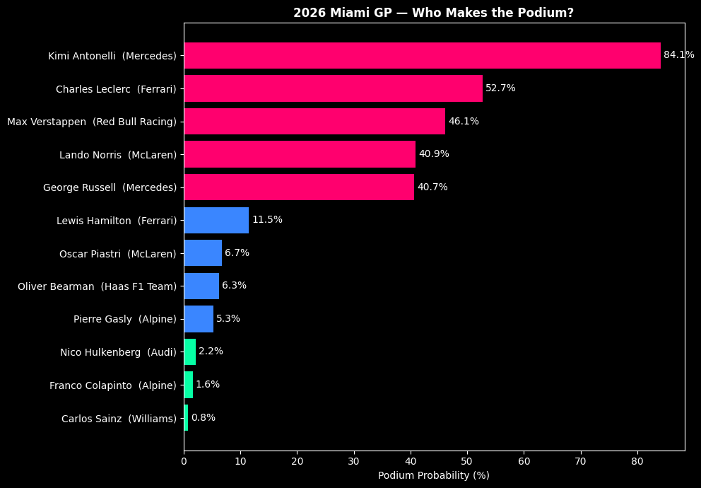

## 4. Race Results & Model Accuracy

The race has run — time to grade the model. Predicted order against the official classification: position-by-position error, podium / top-5 / top-10 accuracy, and the standout calls and misses. These numbers feed the season scoreboard.

```
=====================================================================================
  🏁 OFFICIAL RESULTS vs MODEL — 2026 Miami GP
=====================================================================================

  Fin  Driver                  Team                Pred   Err  Status
  ------------------------------------------------------------------------------
  P 1  Kimi Antonelli          Mercedes            P 1     0  Finished 🎯
  P 2  Lando Norris            McLaren             P 3     1  Finished
  P 3  Oscar Piastri           McLaren             P 7     4  Finished
  P 4  George Russell          Mercedes            P 5     1  Finished
  P 5  Max Verstappen          Red Bull Racing     P 4     1  Finished
  P 6  Lewis Hamilton          Ferrari             P 6     0  Finished 🎯
  P 7  Franco Colapinto        Alpine              P11     4  Finished
  P 8  Charles Leclerc         Ferrari             P 2     6  Finished
  P 9  Carlos Sainz            Williams            P12     3  Finished
  P10  Alexander Albon         Williams            P16     6  Finished
  P11  Oliver Bearman          Haas F1 Team        P 8     3  Lapped
  P12  Gabriel Bortoleto       Audi                P18     6  Lapped
  P13  Esteban Ocon            Haas F1 Team        P13     0  Lapped 🎯
  P14  Arvid Lindblad          Racing Bulls        P17     3  Lapped
  P15  Fernando Alonso         Aston Martin        P20     5  Lapped
  P16  Sergio Perez            Cadillac            P21     5  Lapped
  P17  Lance Stroll            Aston Martin        P19     2  Lapped
  P18  Valtteri Bottas         Cadillac            P22     4  Lapped
  P19  Nico Hulkenberg         Audi                P10   DNF  Retired
  P20  Liam Lawson             Racing Bulls        P14   DNF  Retired
  P21  Pierre Gasly            Alpine              P 9   DNF  Retired
  P22  Isack Hadjar            Red Bull Racing     P15   DNF  Retired

  📊 SCORECARD
  ------------------------------------------------------------
  Predicted winner:  Kimi Antonelli
  Actual winner:     Kimi Antonelli  ✅
  Podium accuracy:   2/3
  Top 5 accuracy:    4/5   (grid baseline: 4/5)
  Top 10 accuracy:   7/10  (grid baseline: 8/10)
  MAE (classified):  3.00 positions  (validation expected 2.37)

  🏁 vs GRID BASELINE (does the model beat 'finish = qualifying order'?)
  Grid-copy MAE:     2.56 positions
  Model edge:        -0.44  ->  grid beats model

  🎯 Best calls:   Kimi Antonelli (P1→P1), Lewis Hamilton (P6→P6), Esteban Ocon (P13→P13)
  💥 Worst misses: Charles Leclerc (pred P2, fin P8), Alexander Albon (pred P16, fin P10), Gabriel Bortoleto (pred P18, fin P12)
  🔧 DNFs: Nico Hulkenberg, Liam Lawson, Pierre Gasly, Isack Hadjar
```

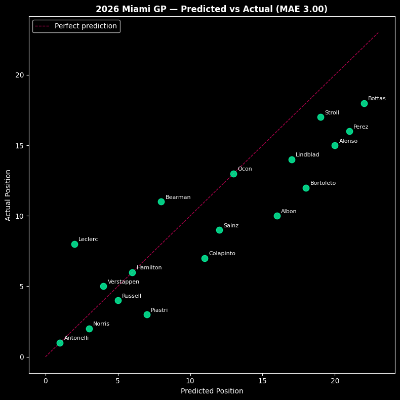